# RPQ analysis - Mindset

Yizhou Yu

NA

The Rivermead Post-concussion Symptoms Questionnaire (RPQ) is a widely used tool for assessment of the presence and severity of various post-concussion symptoms. The questionnaire was first published in 1995 to assess patients’ psychosocial functioning post-concussion. It contains 16 questions targeting physical, cognitive and behavioural domains. It was modified by Eyres et al. is 2005 into RPQ Modified Scoring System (RPQ 13/ RPQ-3)

Workflow: - Descriptive statistics - Do individuals with recent concussions score high on RPQ3 and whether anyone with less recent concussion symptoms? - Identify the main questions involved in the RPQ (13 and 3) - See whether fewer questions in addition to the Mscores could predict the RPQ parameters.

## Data curation

load libraries

```r
library(tidyverse)
library(ggplot2)
library(pdp)
library(rpart.plot)
library(caret)
library(dplyr)
```

## Data curation load data  
Note: in the metadt, when use == 2, the variables will have multiple components

```r
metadt = read.csv("metadt.csv")
metadt = subset(metadt, use == 1)
dt_raw = read.csv("dt/NK_14_04_2021.csv")
dt <- dt_raw[, metadt$varname]
```

Add additional data:

Add RPQ questions: RPQ_Q1-16

“RPQ_Q1_CORRECTED” “RPQ_Q2_CORRECTED” “RPQ_Q3_CORRECTED” “RPQ_Q4_CORRECTED” “RPQ_Q5_CORRECTED” “RPQ_Q6_CORRECTED” “RPQ_Q7_CORRECTED” “RPQ_Q8_CORRECTED” “RPQ_Q9_CORRECTED” “RPQ_Q10_CORRECTED” “RPQ_Q11_CORRECTED” “RPQ_Q12_CORRECTED” “RPQ_Q13_CORRECTED” “RPQ_Q14_CORRECTED” “RPQ_Q15_CORRECTED” “RPQ_Q16_CORRECTED”  
“RPQ_TOT_CORRECTED” “RPQ13_CORRECTED”

```r
rpq_q_list = c()

for (i in 1:16){
  rpq_question = paste("RPQ_Q", i, "_CORRECTED", sep = "")
  rpq_q_list = c(rpq_q_list, rpq_question)
}
rpq_dt = subset(read.csv("dt/NK_14_04_2021.csv"), select = rpq_q_list)
head(rpq_dt,2)
```

```
##   RPQ_Q1_CORRECTED RPQ_Q2_CORRECTED RPQ_Q3_CORRECTED RPQ_Q4_CORRECTED
## 1               NA               NA               NA               NA
## 2               NA               NA               NA               NA
##   RPQ_Q5_CORRECTED RPQ_Q6_CORRECTED RPQ_Q7_CORRECTED RPQ_Q8_CORRECTED
## 1               NA               NA               NA               NA
## 2               NA               NA               NA               NA
##   RPQ_Q9_CORRECTED RPQ_Q10_CORRECTED RPQ_Q11_CORRECTED RPQ_Q12_CORRECTED
## 1               NA                NA                NA                NA
## 2               NA                NA                NA                NA
##   RPQ_Q13_CORRECTED RPQ_Q14_CORRECTED RPQ_Q15_CORRECTED RPQ_Q16_CORRECTED
## 1                NA                NA                NA                NA
## 2                NA                NA                NA                NA
```

```r
subset(read.csv("metadt.csv"), use == 2)
```

```
##            varname                                          description use
## 4    MCI_Condition                                  MCI Risk Q multiple   2
## 24 neuro_Condition clicked I have (condition) (neurological Conditions)   2
## 25    MH_Condition           clicked I have (condition) (mental health)   2
##         type notes
## 4  cognitive   MCQ
## 24             MCQ
## 25             MCQ
```

```r
dt_mci = dt_raw %>% select(starts_with("MCI_"))
dt_neuro = dt_raw %>% select(starts_with("neuro_"))
dt_RPQ = dt_raw %>% select(starts_with("RPQ"))
dt_neuro$neuro_TOT = rowSums(dt_neuro)
dt_MH = dt_raw %>% select(starts_with("MH_"))
dt_MH$MH_TOT = rowSums(dt_MH)
```

```r
#dt = cbind(dt,dt_mci) # use MCI_TOT instead
dt$neuro_TOT = dt_neuro[,"neuro_TOT"]
dt$MH_TOT = dt_MH[,"MH_TOT"]
```

exclude scores

```r
exclude_vars <- names(dt) %in% c("CAGE_TOT", #alcohol
                                    "GAD7_TOT", #anxiety
                                    "PHQ2_TOT", #depression
                                    "PHQ9_TOT") #depression
dt_noS = dt[,!exclude_vars]
head(dt_noS)
```

```
##          BM7 RPQ_TOT age ageStroopQscore              concussions covidPositive
## 1 0.06945039      NA  46              26                             ResponseNo
## 2         NA      NA  56              13                             ResponseNo
## 3 0.04826466       0  42              10 New_User_ConcussionB_2_3    ResponseNo
## 4 0.06053405      48  69              18 New_User_ConcussionB_2_3    ResponseNo
## 5 0.05276539      11  61              34 New_User_ConcussionB_4_5   ResponseYes
## 6 0.08377164      NA  65              14                             ResponseNo
##           dementia hadConcussion                     joke
## 1      ResponseYes             N              ResponseYes
## 2      ResponseYes             N              ResponseYes
## 3       ResponseNo             Y              ResponseYes
## 4 ResponseDontKnow             Y              ResponseYes
## 5       ResponseNo             Y               ResponseNo
## 6      ResponseYes             N New_User_Joke_006_Action
##                    memory RPQ_TOT_CORRECTED RPQ13_CORRECTED RPQ3_CORRECTED
```

[output cut: 20 more lines]

## Descriptive data

[figure not shown]

```r
num_graph = dt_noS %>%
  keep(is.numeric)
discrete_graph = dt_noS[ , !(names(dt_noS) %in% colnames(num_graph))]

discrete_graph_gather = discrete_graph %>%
  gather()

ggplot(discrete_graph_gather, aes(value)) +
    facet_wrap(~ key, scales = "free") +
    geom_histogram(stat = "count",fill="#939598",color="#939598") +
    theme(
      text = element_text(colour = "#231F20"),
      strip.background =element_rect(fill="transparent"),
      axis.text.x = element_text(angle = 90,color = "#231F20"),
      #axis.text.x = element_text(colour = "#231F20"),
      axis.text.y = element_text(colour = "#231F20"),
      panel.background = element_rect(fill = "transparent"), # bg of the panel
      plot.background = element_rect(fill = "transparent", color = NA), # bg of the plot
      panel.grid.major = element_blank(), # get rid of major grid
      panel.grid.minor = element_blank())# get rid of minor grid coord_flip()
```

```r
ggsave('fig/dt_distribution_discrete.pdf', width = 8, height = 10)
```

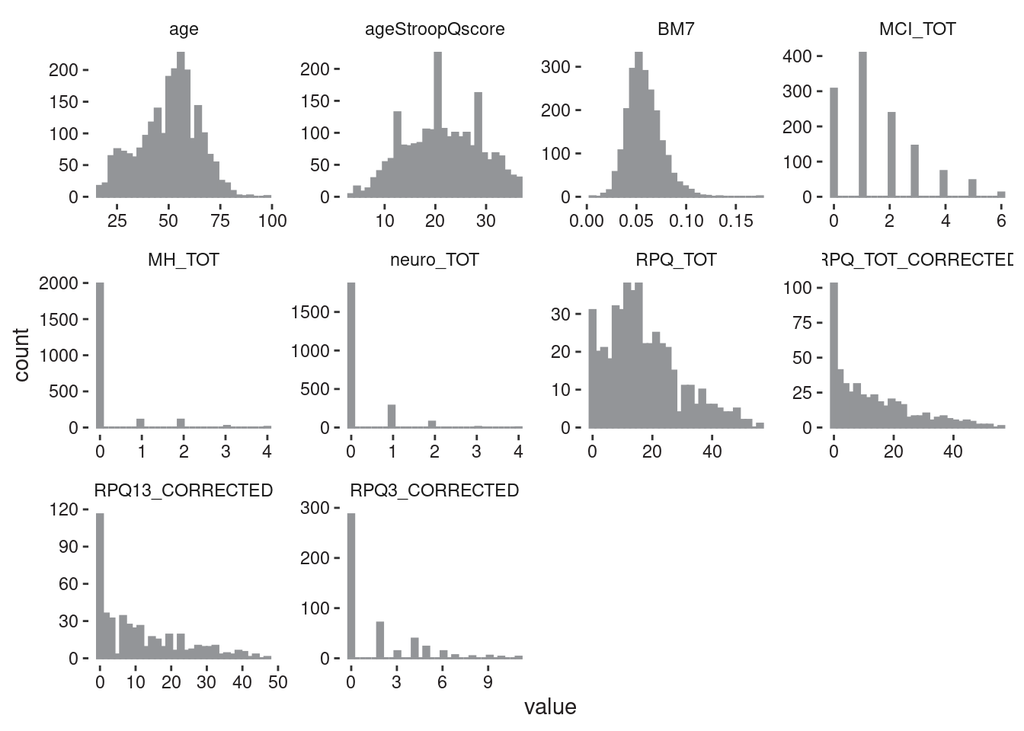

```r
num_graph %>%
  gather() %>%
  ggplot(aes(value)) +
    facet_wrap(~ key, scales = "free") +
    geom_histogram(fill="#939598",color="#939598") +
    theme(
      text = element_text(colour = "#231F20"),
      axis.text.x = element_text(colour = "#231F20"),
      axis.text.y = element_text(colour = "#231F20"),
      strip.background =element_rect(fill="transparent"),
      panel.background = element_rect(fill = "transparent"), # bg of the panel
      plot.background = element_rect(fill = "transparent", color = NA), # bg of the plot
      panel.grid.major = element_blank(), # get rid of major grid
      panel.grid.minor = element_blank())# get rid of minor grid
```

```r
ggsave('fig/dt_distribution_continuous.pdf', width = 6.3, height = 7)
nrow(na.omit(dt_noS))
```

```
## [1] 239
```

## Recent concussion and RPQ questions

Reformat the data: I assume that Less than 1 year => recent, and more than 1 year => previous

```r
concussion_subanalysis = subset(dt_noS, select = c(age,mostRecentConcussion,
                                                   RPQ3_CORRECTED,
                                                   RPQ13_CORRECTED))
concussion_subanalysis_dt = na.omit(concussion_subanalysis)
concussion_subanalysis_dt$recent_concussion = with(concussion_subanalysis_dt, ifelse(mostRecentConcussion %in%
                                                 c("New_User_ConcussionC_1",
                                                   "New_User_ConcussionC_2"), TRUE, FALSE))
```

Scale: RPQ3 is out of 12, and RPQ13 is out of 52

```r
concussion_subanalysis_dt$norm_RPQ3 = concussion_subanalysis_dt$RPQ3_CORRECTED/12
concussion_subanalysis_dt$norm_RPQ13 = concussion_subanalysis_dt$RPQ13_CORRECTED/52
```

```r
summary(norm_RPQ3_lm <- lm(data = concussion_subanalysis_dt, norm_RPQ3 ~ recent_concussion + age))
```

```
##
## Call:
## lm(formula = norm_RPQ3 ~ recent_concussion + age, data = concussion_subanalysis_dt)
##
## Residuals:
##     Min      1Q  Median      3Q     Max
## -0.2425 -0.1259 -0.1137  0.0559  0.8109
##
## Coefficients:
##                        Estimate Std. Error t value Pr(>|t|)
## (Intercept)           0.0891010  0.0340363   2.618  0.00914 **
## recent_concussionTRUE 0.1057319  0.0428839   2.466  0.01404 *
## age                   0.0007223  0.0006931   1.042  0.29786
## ---
## Signif. codes:  0 '***' 0.001 '**' 0.01 '*' 0.05 '.' 0.1 ' ' 1
##
## Residual standard error: 0.1962 on 466 degrees of freedom
## Multiple R-squared:  0.01476,    Adjusted R-squared:  0.01053
## F-statistic:  3.49 on 2 and 466 DF,  p-value: 0.03129
```

```r
wilcox.test(concussion_subanalysis_dt$norm_RPQ3 ~ concussion_subanalysis_dt$recent_concussion)
```

```
##
##  Wilcoxon rank sum test with continuity correction
##
## data:  concussion_subanalysis_dt$norm_RPQ3 by concussion_subanalysis_dt$recent_concussion
## W = 3951.5, p-value = 0.07575
## alternative hypothesis: true location shift is not equal to 0
```

```r
confint(norm_RPQ3_lm)
```

```
##                               2.5 %     97.5 %
## (Intercept)            0.0222172960 0.15598465
## recent_concussionTRUE  0.0214621803 0.19000164
## age                   -0.0006396506 0.00208434
```

```r
wilcox.test(concussion_subanalysis_dt$norm_RPQ13 ~ concussion_subanalysis_dt$recent_concussion)
```

```
##
##  Wilcoxon rank sum test with continuity correction
##
## data:  concussion_subanalysis_dt$norm_RPQ13 by concussion_subanalysis_dt$recent_concussion
## W = 4502, p-value = 0.5007
## alternative hypothesis: true location shift is not equal to 0
```

```r
prev_conc_lm = lm(data = concussion_subanalysis_dt, norm_RPQ13 ~ age + recent_concussion)
summary(prev_conc_lm)
```

```
##
## Call:
## lm(formula = norm_RPQ13 ~ age + recent_concussion, data = concussion_subanalysis_dt)
##
## Residuals:
##      Min       1Q   Median       3Q      Max
## -0.26774 -0.19019 -0.06442  0.14346  0.68436
##
## Coefficients:
##                        Estimate Std. Error t value Pr(>|t|)
## (Intercept)           0.1596769  0.0384281   4.155 3.87e-05 ***
## age                   0.0012206  0.0007825   1.560    0.119
## recent_concussionTRUE 0.0433733  0.0484172   0.896    0.371
## ---
## Signif. codes:  0 '***' 0.001 '**' 0.01 '*' 0.05 '.' 0.1 ' ' 1
##
## Residual standard error: 0.2215 on 466 degrees of freedom
## Multiple R-squared:  0.006681,   Adjusted R-squared:  0.002418
## F-statistic: 1.567 on 2 and 466 DF,  p-value: 0.2097
```

```r
rec_conc_lm = lm(data = concussion_subanalysis_dt, norm_RPQ3 ~ age + recent_concussion)
summary(rec_conc_lm)
```

```
##
## Call:
## lm(formula = norm_RPQ3 ~ age + recent_concussion, data = concussion_subanalysis_dt)
##
## Residuals:
##     Min      1Q  Median      3Q     Max
## -0.2425 -0.1259 -0.1137  0.0559  0.8109
##
## Coefficients:
##                        Estimate Std. Error t value Pr(>|t|)
## (Intercept)           0.0891010  0.0340363   2.618  0.00914 **
## age                   0.0007223  0.0006931   1.042  0.29786
## recent_concussionTRUE 0.1057319  0.0428839   2.466  0.01404 *
## ---
## Signif. codes:  0 '***' 0.001 '**' 0.01 '*' 0.05 '.' 0.1 ' ' 1
##
## Residual standard error: 0.1962 on 466 degrees of freedom
## Multiple R-squared:  0.01476,    Adjusted R-squared:  0.01053
## F-statistic:  3.49 on 2 and 466 DF,  p-value: 0.03129
```

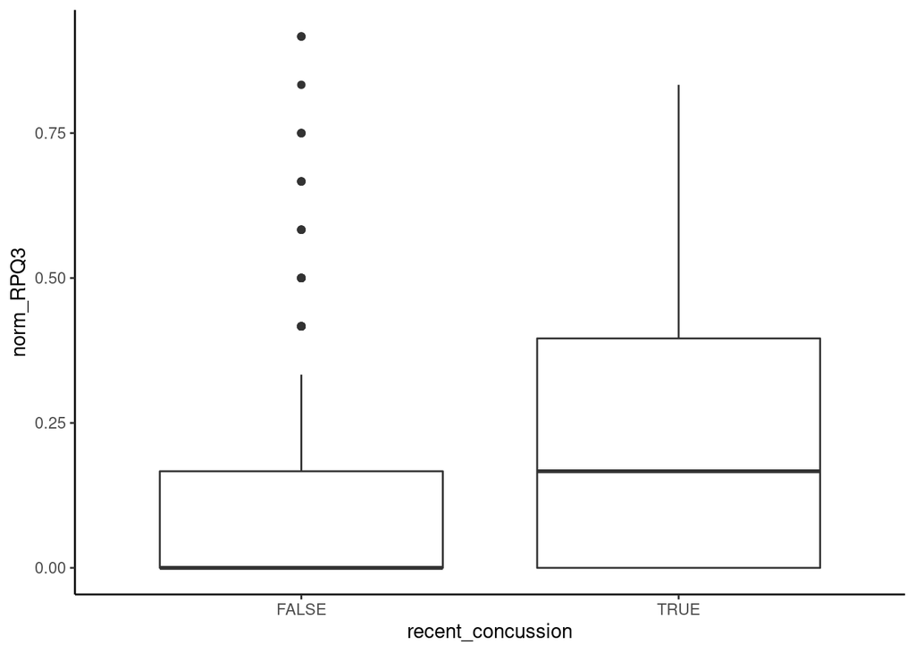

```r
ggplot(data = concussion_subanalysis_dt, aes(x=recent_concussion, y=norm_RPQ3)) +
  geom_boxplot()+ theme_classic()+
  theme(
    panel.background = element_rect(fill = "transparent"), # bg of the panel
    plot.background = element_rect(fill = "transparent", color = NA), # bg of the plot
    panel.grid.major = element_blank(), # get rid of major grid
    panel.grid.minor = element_blank(), # get rid of minor grid
    legend.background = element_rect(fill = "transparent"), # get rid of legend bg
    legend.box.background = element_rect(fill = "transparent") # get rid of legend panel bg
  )
```

```r
ggsave("fig/RPQ3_recent_concussion_validation.pdf", width = 2, height = 2,  bg = "transparent")
```

Conclusion: a recent concussion is associated with higher RPQ3 score (estimate = 0.1057319), but a previous concussion is not associated with a higher RPQ13 score, indicating that perhaps some people might be recovering well, while others are not. It might be interesting to explore this further.

### Further analyses on RPQ3

I did not pursue further tests only on RPQ3 because there were only 22 individuals

```r
rpq3_analysis_subset = dt

rpq3_analysis_subset$recent_concussion = with(rpq3_analysis_subset, ifelse(mostRecentConcussion %in%
                                                 c("New_User_ConcussionC_1",
                                                   "New_User_ConcussionC_2"), TRUE, FALSE))
rpq3_analysis_subset = subset(rpq3_analysis_subset, recent_concussion == TRUE)
nrow(rpq3_analysis_subset)
```

```
## [1] 22
```

```r
# run a for loop to screen for all confounders one by one
variable_list = colnames(rpq3_analysis_subset)
variable_list = variable_list[variable_list != "age"]
variable_list = variable_list[variable_list != "hadConcussion"]
variable_list = variable_list[variable_list != "RPQ3_CORRECTED"]

Estimate=c()
Std..Error=c()
t.value=c()
Pr...t..=c()
var_names=c()

sumamry_list = data.frame(Estimate,Std..Error,t.value,Pr...t..,var_names)
for (var in 1:length(variable_list)){
  var_name = variable_list[var]
  lm_formula = as.formula(
    paste("RPQ3_CORRECTED",paste(c("age" , var_name), collapse = " + "),sep = " ~ ")
  )
  # print(lm_formula)
  summary_var = summary(rpq3_subanalysis_lm <- lm(formula = lm_formula, data = rpq3_analysis_subset))
  summary_df = data.frame(summary_var$coefficients)
  summary_df$var_names = row.names(summary_df)
  summary_df_clean = subset(summary_df, !(var_names %in%
                                            c('(Intercept)','age')))
  sumamry_list = rbind(sumamry_list,summary_df_clean)
}
```

```r
sumamry_list_significant = subset(sumamry_list, Pr...t.. <= 0.05)
sumamry_list_significant
```

```
##                                              Estimate Std..Error   t.value
## RPQ_TOT                                     0.2573014 0.03661913  7.026420
## memoryEnd_Sequence_002_Photo3               8.4268675 3.47180601  2.427229
## RPQ_TOT_CORRECTED                           0.1976488 0.03654014  5.409087
## RPQ13_CORRECTED                             0.1990855 0.05460795  3.645724
## mostRecentConcussionNew_User_ConcussionC_2 -3.7406137 1.33927615 -2.793012
## neuro_TOT                                   3.9864421 1.03263132  3.860470
##                                                Pr...t..
## RPQ_TOT                                    1.088426e-06
## memoryEnd_Sequence_002_Photo3              2.532646e-02
## RPQ_TOT_CORRECTED                          3.214733e-05
## RPQ13_CORRECTED                            1.719799e-03
## mostRecentConcussionNew_User_ConcussionC_2 1.159885e-02
## neuro_TOT                                  1.053774e-03
##                                                                             var_names
## RPQ_TOT                                                                       RPQ_TOT
## memoryEnd_Sequence_002_Photo3                           memoryEnd_Sequence_002_Photo3
## RPQ_TOT_CORRECTED                                                   RPQ_TOT_CORRECTED
## RPQ13_CORRECTED                                                       RPQ13_CORRECTED
## mostRecentConcussionNew_User_ConcussionC_2 mostRecentConcussionNew_User_ConcussionC_2
## neuro_TOT                                                                   neuro_TOT
```

Having a neurological condition seem to increase the RPQ score

```r
# summary(rpq3_subanalysis_lm_neuro <- lm(formula = (RPQ3_CORRECTED)/12 ~
#                                     age + neuro_TOT, data = rpq3_analysis_subset))
rpq3_analysis_subset_plot = rpq3_analysis_subset
rpq3_analysis_subset_plot$neuro_condition = with(rpq3_analysis_subset_plot, ifelse(neuro_TOT >= 1, TRUE, FALSE))

summary(rpq3_subanalysis_lm_neuro <- lm(formula = (RPQ3_CORRECTED)/12 ~
                                    age + neuro_condition, data = rpq3_analysis_subset_plot))
```

```
##
## Call:
## lm(formula = (RPQ3_CORRECTED)/12 ~ age + neuro_condition, data = rpq3_analysis_subset_plot)
##
## Residuals:
##      Min       1Q   Median       3Q      Max
## -0.42696 -0.12817 -0.03316  0.15637  0.38351
##
## Coefficients:
##                      Estimate Std. Error t value Pr(>|t|)
## (Intercept)          0.210313   0.136845   1.537 0.140811
## age                 -0.002857   0.002899  -0.986 0.336740
## neuro_conditionTRUE  0.399516   0.102181   3.910 0.000941 ***
## ---
## Signif. codes:  0 '***' 0.001 '**' 0.01 '*' 0.05 '.' 0.1 ' ' 1
##
## Residual standard error: 0.2259 on 19 degrees of freedom
## Multiple R-squared:  0.4466, Adjusted R-squared:  0.3883
## F-statistic: 7.666 on 2 and 19 DF,  p-value: 0.003623
```

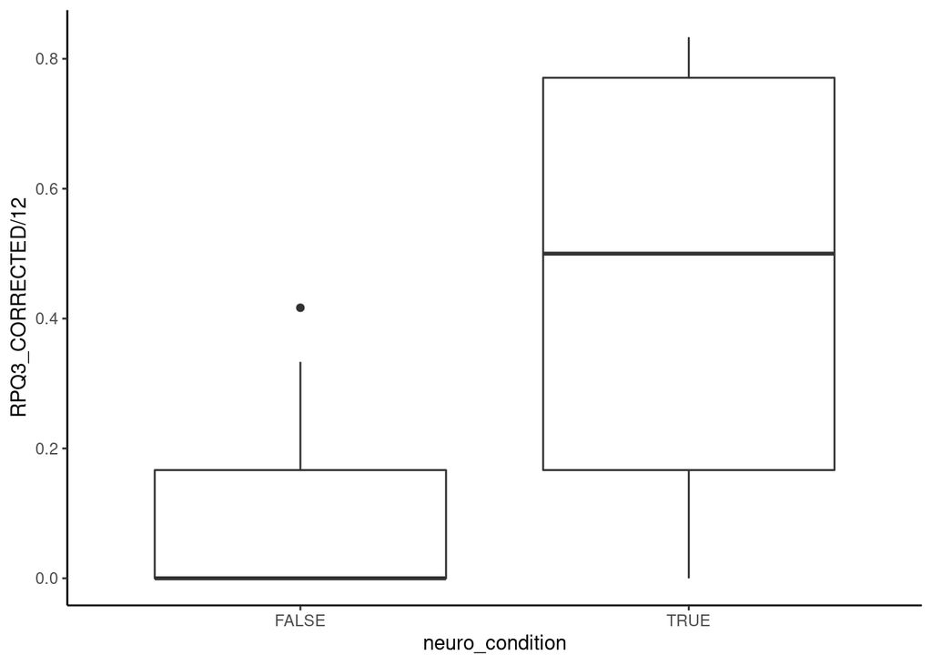

```r
ggplot(data = rpq3_analysis_subset_plot, aes(x=neuro_condition, y=RPQ3_CORRECTED/12)) +
  geom_boxplot() + theme_classic()+
  theme(
    panel.background = element_rect(fill = "transparent"), # bg of the panel
    plot.background = element_rect(fill = "transparent", color = NA), # bg of the plot
    panel.grid.major = element_blank(), # get rid of major grid
    panel.grid.minor = element_blank(), # get rid of minor grid
    legend.background = element_rect(fill = "transparent"), # get rid of legend bg
    legend.box.background = element_rect(fill = "transparent") # get rid of legend panel bg
  )
```

```r
ggsave("fig/RPQ3_subanalysis_neuro_condition.pdf", width = 2, height = 2,  bg = "transparent")
```

```r
confint(rpq3_subanalysis_lm_neuro)
```

```
##                            2.5 %    97.5 %
## (Intercept)         -0.076106706 0.4967328
## age                 -0.008925414 0.0032108
## neuro_conditionTRUE  0.185648734 0.6133842
```

```r
length(rpq3_analysis_subset_plot$neuro_condition[rpq3_analysis_subset_plot$neuro_condition== TRUE])
```

```
## [1] 8
```

8 have neurological condition and 22-8 = 14 do not.

## Simplification of RPQ3

```r
rpq3_subanalysis = cbind(subset(dt_noS, select = c(RPQ3_CORRECTED)),rpq_dt[,1:3])
```

Do a PCA for RPQ3

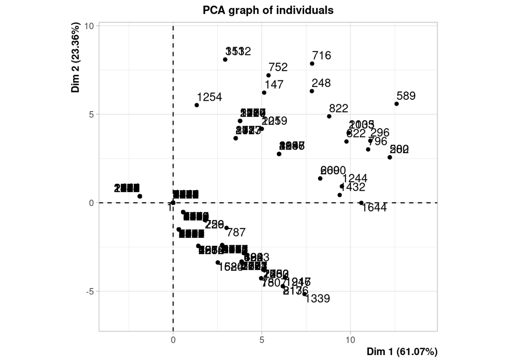

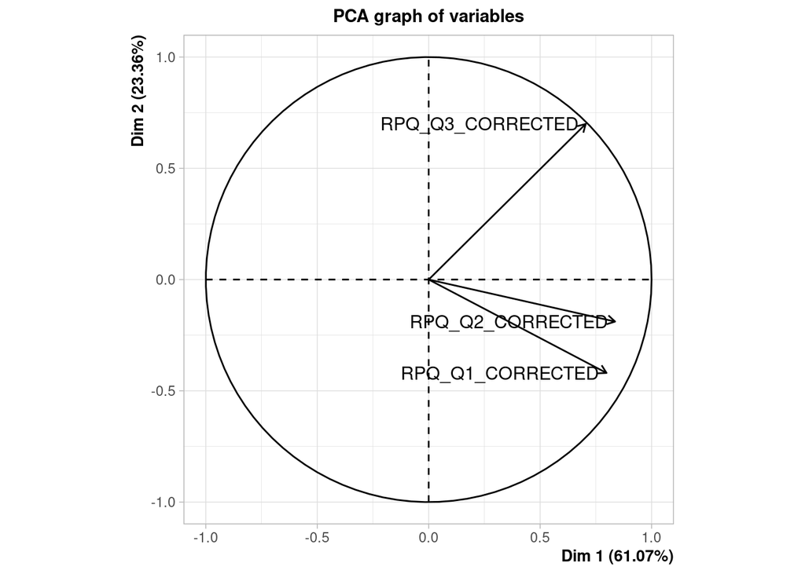

```r
RPQ3_pca = FactoMineR::PCA(rpq3_subanalysis[,-1], scale.unit = TRUE, ncp = 5, graph = TRUE)
```

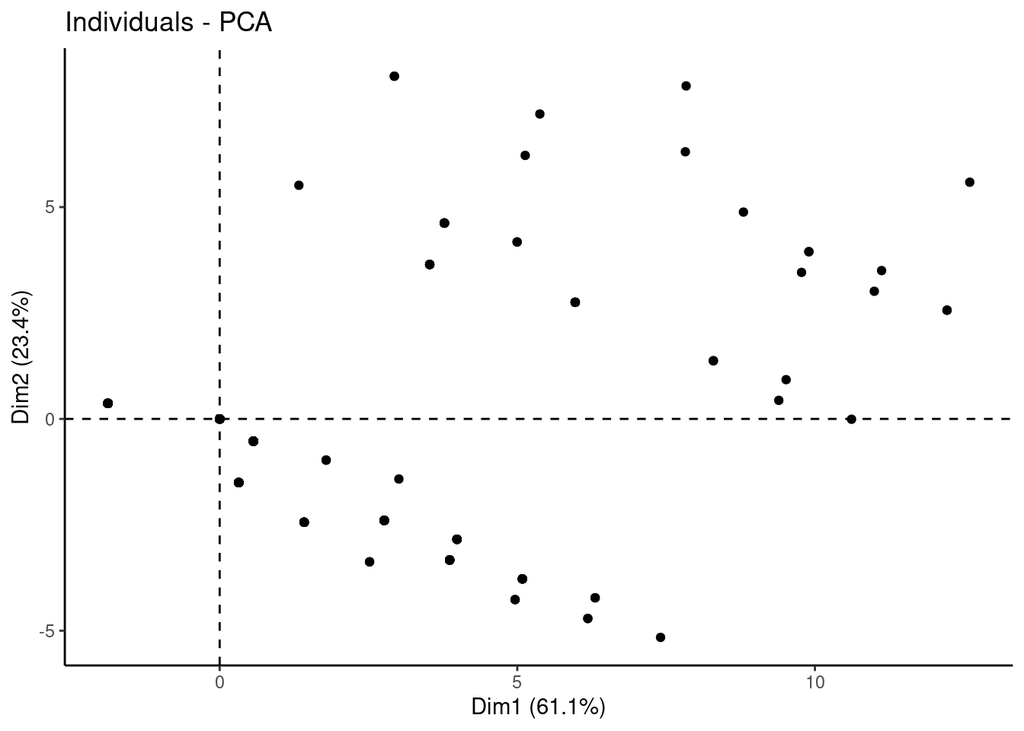

```r
factoextra::fviz_pca_ind(RPQ3_pca,
             geom.ind = "point", # show points only (nbut not "text")
             ) + theme_classic()+
  theme(
    panel.background = element_rect(fill = "transparent"), # bg of the panel
    plot.background = element_rect(fill = "transparent", color = NA), # bg of the plot
    panel.grid.major = element_blank(), # get rid of major grid
    panel.grid.minor = element_blank(), # get rid of minor grid
    legend.background = element_rect(fill = "transparent"), # get rid of legend bg
    legend.box.background = element_rect(fill = "transparent") # get rid of legend panel bg
  )
```

```r
ggsave("fig/RPQ3_PCA_general_graph.pdf", width = 3, height = 2,  bg = "transparent")
```

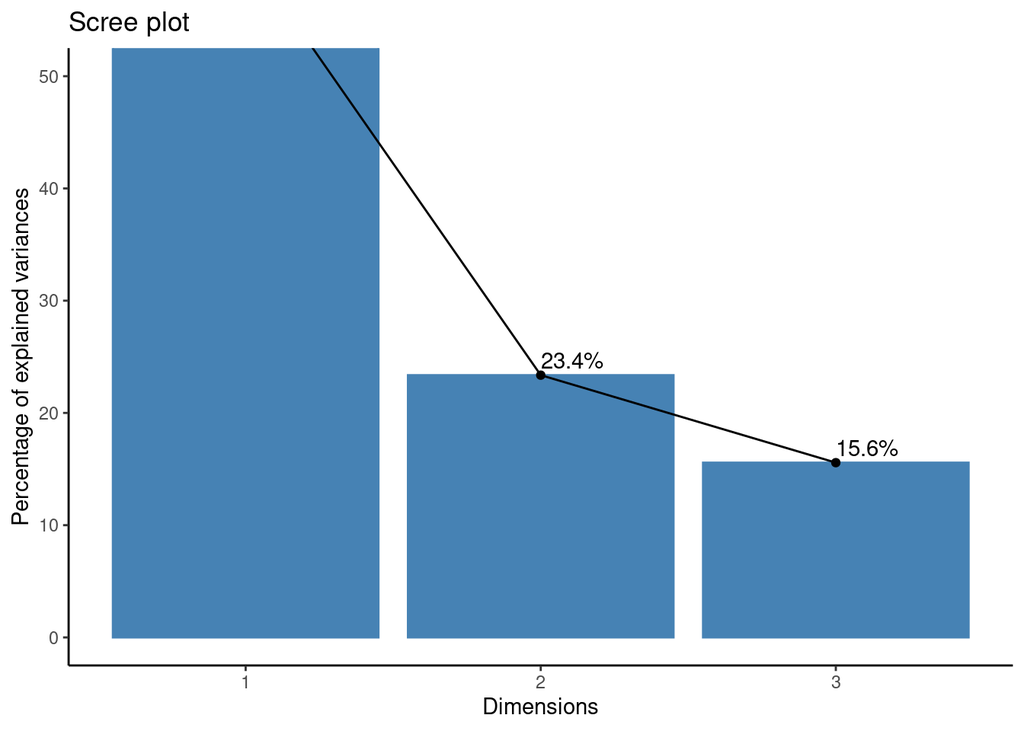

```r
factoextra::fviz_eig(RPQ3_pca, addlabels = TRUE, ylim = c(0, 50)) + theme_classic()
```

```r
ggsave("fig/RPQ3_PCA_components.pdf", width = 3, height = 2,  bg = "transparent")
```

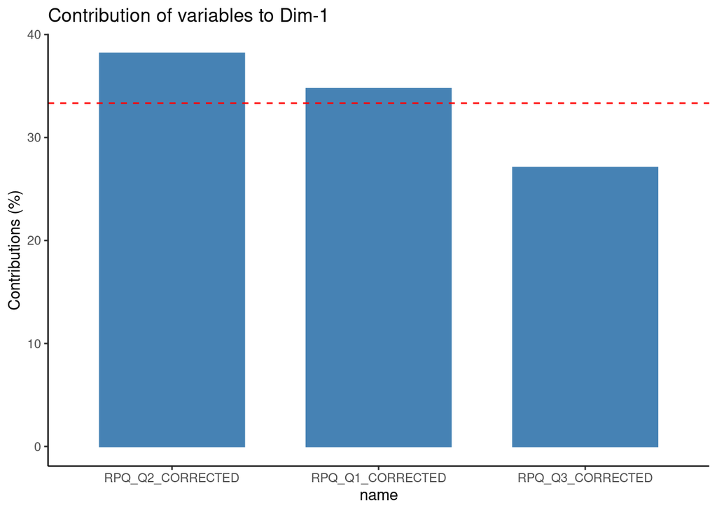

```r
factoextra::fviz_contrib(RPQ3_pca, choice = "var", axes = 1, top = 100) + theme_classic()
```

```r
ggsave("fig/RPQ3_PCA_contribution.pdf", width = 3, height = 2,  bg = "transparent")
```

This shows that RPQ2 is the highest predictor of RPQ3.  
Q2 is : Compared with before the accident, do you now (i.e., over the last 24 hours) suffer from Feelings of Dizziness

Q1 is Headaches and Q3 is Nausea

### RPQ - Q2 and RPQ3

```r
rpq3_validation = cbind(dt_noS,rpq_dt)
rpq3_validation.lm = lm(data = rpq3_validation,RPQ3_CORRECTED~RPQ_Q2_CORRECTED + age)
summary(rpq3_validation.lm)
```

```
##
## Call:
## lm(formula = RPQ3_CORRECTED ~ RPQ_Q2_CORRECTED + age, data = rpq3_validation)
##
## Residuals:
##     Min      1Q  Median      3Q     Max
## -3.6228 -0.3984 -0.3537  0.0020  6.6463
##
## Coefficients:
##                   Estimate Std. Error t value Pr(>|t|)
## (Intercept)       0.498953   0.220397   2.264    0.024 *
## RPQ_Q2_CORRECTED  1.810986   0.053326  33.961   <2e-16 ***
## age              -0.002793   0.004499  -0.621    0.535
## ---
## Signif. codes:  0 '***' 0.001 '**' 0.01 '*' 0.05 '.' 0.1 ' ' 1
##
## Residual standard error: 1.271 on 466 degrees of freedom
##   (1766 observations deleted due to missingness)
## Multiple R-squared:  0.7128, Adjusted R-squared:  0.7115
## F-statistic: 578.2 on 2 and 466 DF,  p-value: < 2.2e-16
```

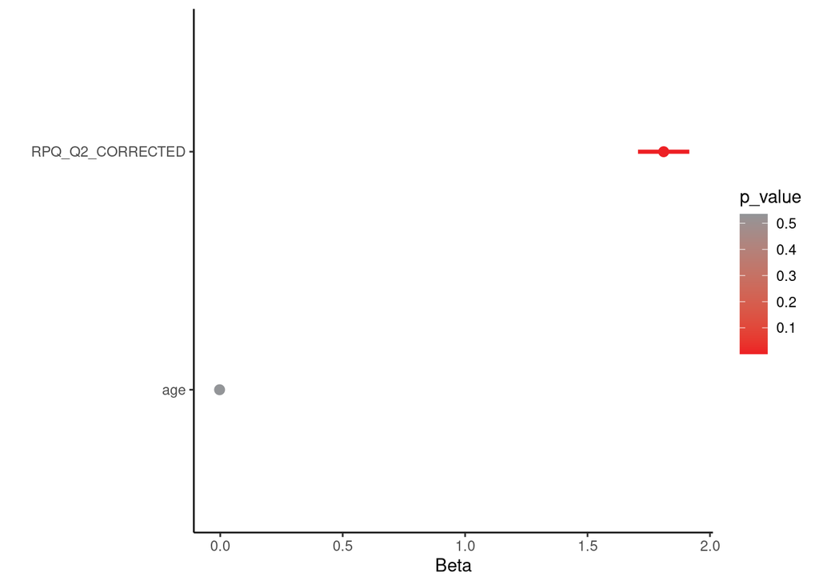

```r
# rpq3_validation.lm

rpq3_validation.lm_dt = data.frame(cbind((cbind(Beta = coef(rpq3_validation.lm),
                                                confint(rpq3_validation.lm))), p_value = summary(rpq3_validation.lm)$coefficients[,4]))

rpq3_validation.lm_dt$significance = "p-value > 0.05"
rpq3_validation.lm_dt$significance[rpq3_validation.lm_dt$p_value < 0.05] <- "p-value < 0.05"
rpq3_validation.lm_dt$name= row.names(rpq3_validation.lm_dt)
rpq3_validation.lm_dt = subset(rpq3_validation.lm_dt, name != "(Intercept)")
ggplot2::ggplot(rpq3_validation.lm_dt,
       aes(x=name, y=Beta, color = p_value, fill = p_value)) +
    geom_point(shape=21, size = 2.5) +
    geom_errorbar(aes(ymin=X2.5.., ymax=X97.5..),
                  width=0,                    # Width of the error bars
                  size = 1.2,
                  position=position_dodge(.9)) +
  scale_color_gradient(
  low = "#ED2024",
  high = "#939598") +
  scale_fill_gradient(
  low = "#ED2024",
  high = "#939598") +
  theme_classic() +
  # geom_hline(yintercept = 1, linetype="dotted") +
  coord_flip()+ylab("Beta") +
  xlab("")
```

```r
ggsave("fig/rpq3_question2_lm.pdf", width = 4, height = 1.5,  bg = "transparent")
```

## Simplification of RPQ13

```r
prev_conc_lm = lm(data = concussion_subanalysis_dt, norm_RPQ13 ~ age + recent_concussion)
summary(prev_conc_lm)
```

```
##
## Call:
## lm(formula = norm_RPQ13 ~ age + recent_concussion, data = concussion_subanalysis_dt)
##
## Residuals:
##      Min       1Q   Median       3Q      Max
## -0.26774 -0.19019 -0.06442  0.14346  0.68436
##
## Coefficients:
##                        Estimate Std. Error t value Pr(>|t|)
## (Intercept)           0.1596769  0.0384281   4.155 3.87e-05 ***
## age                   0.0012206  0.0007825   1.560    0.119
## recent_concussionTRUE 0.0433733  0.0484172   0.896    0.371
## ---
## Signif. codes:  0 '***' 0.001 '**' 0.01 '*' 0.05 '.' 0.1 ' ' 1
##
## Residual standard error: 0.2215 on 466 degrees of freedom
## Multiple R-squared:  0.006681,   Adjusted R-squared:  0.002418
## F-statistic: 1.567 on 2 and 466 DF,  p-value: 0.2097
```

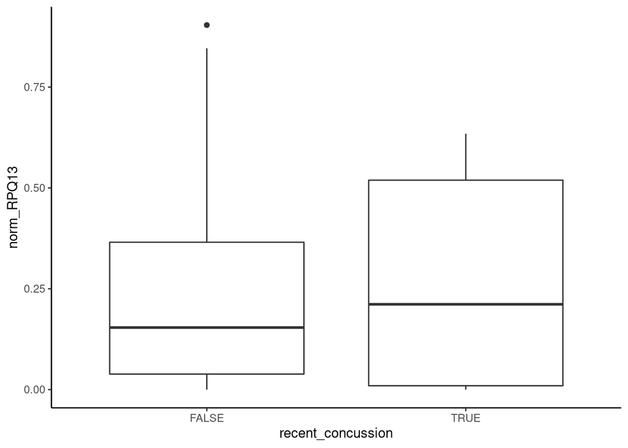

```r
ggplot(data = concussion_subanalysis_dt, aes(x=recent_concussion, y=norm_RPQ13)) +
  geom_boxplot()+ theme_classic()+
  theme(
    panel.background = element_rect(fill = "transparent"), # bg of the panel
    plot.background = element_rect(fill = "transparent", color = NA), # bg of the plot
    panel.grid.major = element_blank(), # get rid of major grid
    panel.grid.minor = element_blank(), # get rid of minor grid
    legend.background = element_rect(fill = "transparent"), # get rid of legend bg
    legend.box.background = element_rect(fill = "transparent") # get rid of legend panel bg
  )
```

```r
ggsave("fig/RPQ13_previous_concussion_validation.pdf", width = 2, height = 2,  bg = "transparent")
```

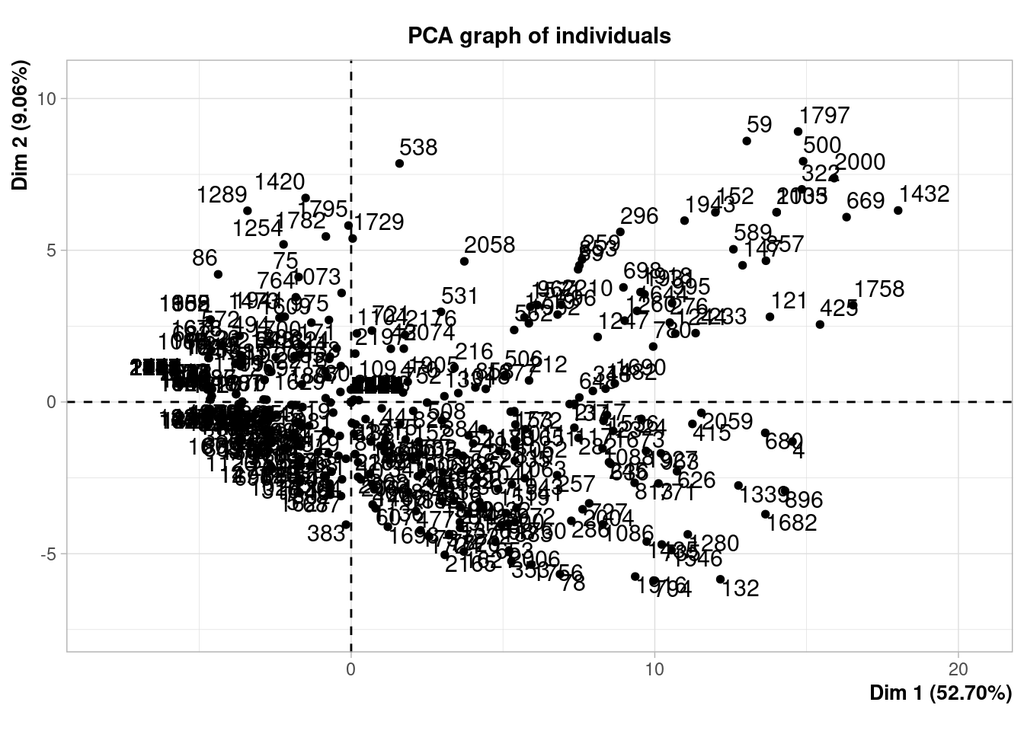

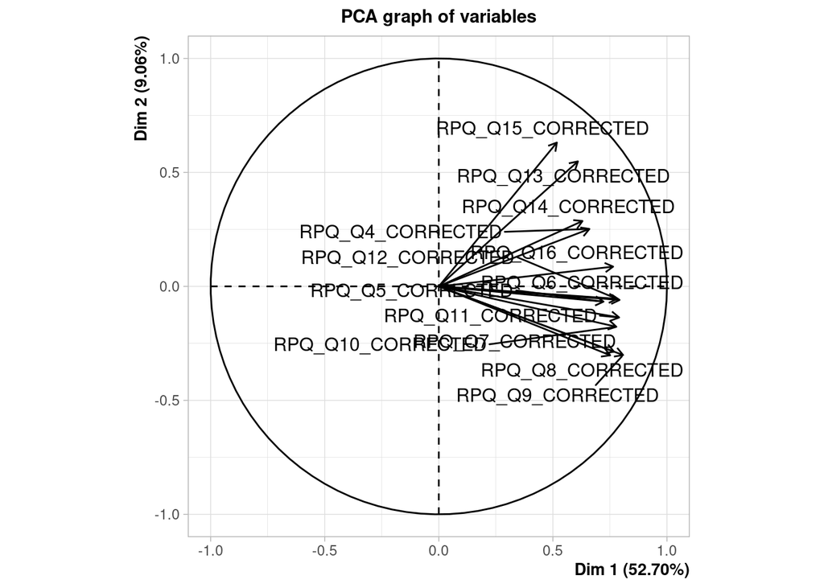

```r
rpq13_subanalysis = cbind(subset(dt_noS, select = c(RPQ13_CORRECTED)),rpq_dt[,4:16])

RPQ13_pca = FactoMineR::PCA(rpq13_subanalysis[,-1], scale.unit = TRUE, ncp = 5, graph = TRUE)
```

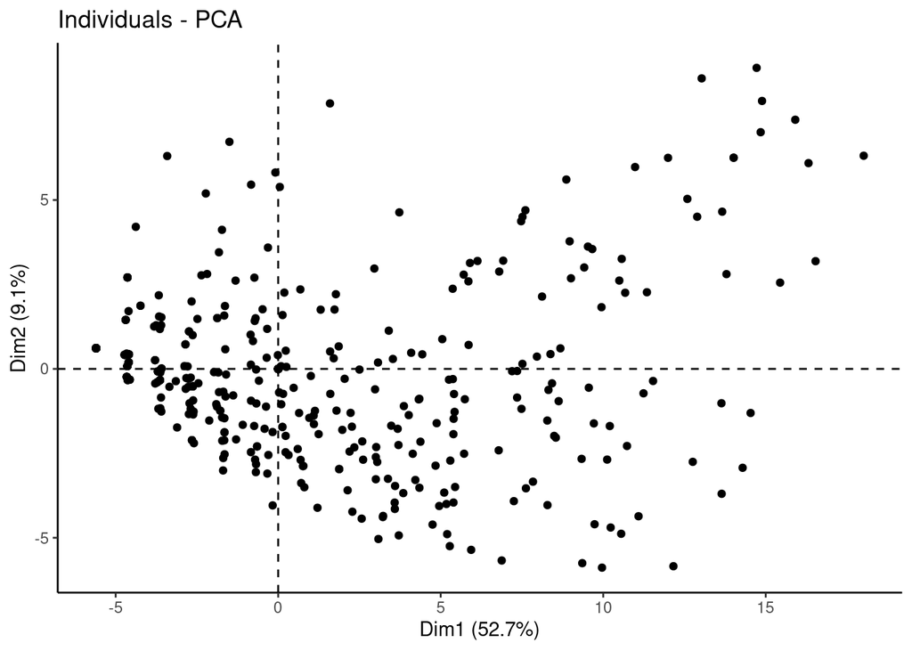

```r
factoextra::fviz_pca_ind(RPQ13_pca,
             geom.ind = "point", # show points only (nbut not "text")
             ) + theme_classic()+
  theme(
    panel.background = element_rect(fill = "transparent"), # bg of the panel
    plot.background = element_rect(fill = "transparent", color = NA), # bg of the plot
    panel.grid.major = element_blank(), # get rid of major grid
    panel.grid.minor = element_blank(), # get rid of minor grid
    legend.background = element_rect(fill = "transparent"), # get rid of legend bg
    legend.box.background = element_rect(fill = "transparent") # get rid of legend panel bg
  )
```

```r
ggsave("fig/RPQ13_PCA_general_graph.pdf", width = 3, height = 2,  bg = "transparent")
```

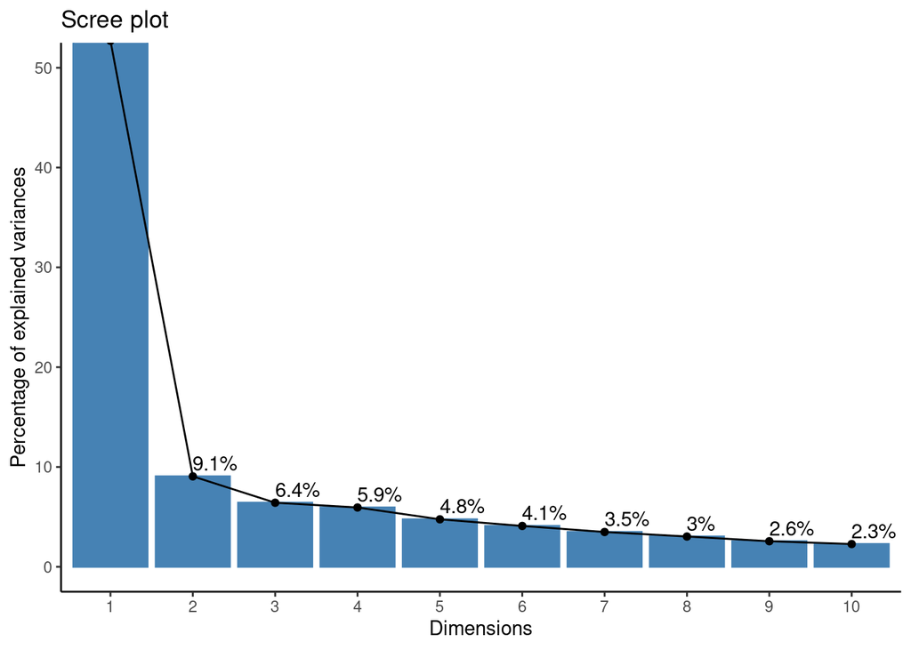

```r
factoextra::fviz_eig(RPQ13_pca, addlabels = TRUE, ylim = c(0, 50))+ theme_classic()
```

```r
ggsave("fig/RPQ13_PCA.pdf", width = 3, height = 2,  bg = "transparent")
```

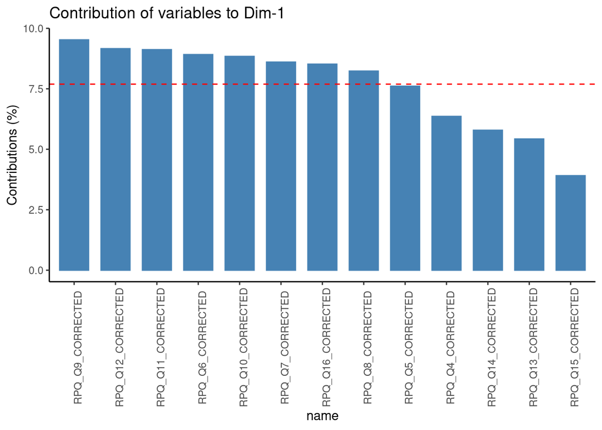

```r
factoextra::fviz_contrib(RPQ13_pca, choice = "var", axes = 1, top = 100) + theme_classic() +
  theme(axis.text.x = element_text(angle = 90))
```

```r
ggsave("fig/RPQ3_PCA_contributions.pdf", width = 3, height = 4,  bg = "transparent")
```

Q1 is Headaches and Q3 is Nausea

### RPQ - Q9 and RPQ13

```r
rpq13_validation = cbind(dt_noS,rpq_dt)
rpq13_validation.lm = lm(data = rpq3_validation,RPQ13_CORRECTED~RPQ_Q9_CORRECTED +
                           RPQ_Q12_CORRECTED +
                           RPQ_Q11_CORRECTED +
                           RPQ_Q6_CORRECTED +
                           RPQ_Q10_CORRECTED +
                           RPQ_Q7_CORRECTED +
                           RPQ_Q16_CORRECTED +
                           RPQ_Q8_CORRECTED)
summary(rpq13_validation.lm)
```

```
##
## Call:
## lm(formula = RPQ13_CORRECTED ~ RPQ_Q9_CORRECTED + RPQ_Q12_CORRECTED +
##     RPQ_Q11_CORRECTED + RPQ_Q6_CORRECTED + RPQ_Q10_CORRECTED +
##     RPQ_Q7_CORRECTED + RPQ_Q16_CORRECTED + RPQ_Q8_CORRECTED,
##     data = rpq3_validation)
##
## Residuals:
##     Min      1Q  Median      3Q     Max
## -8.7508 -1.1863 -0.2795  0.9593  9.6017
##
## Coefficients:
##                   Estimate Std. Error t value Pr(>|t|)
## (Intercept)         0.2795     0.1685   1.659   0.0978 .
## RPQ_Q9_CORRECTED    0.9901     0.1578   6.273 8.18e-10 ***
## RPQ_Q12_CORRECTED   1.5209     0.1439  10.569  < 2e-16 ***
## RPQ_Q11_CORRECTED   1.1338     0.1428   7.938 1.58e-14 ***
## RPQ_Q6_CORRECTED    1.8965     0.1147  16.539  < 2e-16 ***
## RPQ_Q10_CORRECTED   1.0594     0.1420   7.462 4.29e-13 ***
## RPQ_Q7_CORRECTED    1.3525     0.1337  10.113  < 2e-16 ***
## RPQ_Q16_CORRECTED   2.1496     0.1514  14.201  < 2e-16 ***
## RPQ_Q8_CORRECTED    0.9770     0.1401   6.976 1.07e-11 ***
## ---
## Signif. codes:  0 '***' 0.001 '**' 0.01 '*' 0.05 '.' 0.1 ' ' 1
##
## Residual standard error: 2.463 on 460 degrees of freedom
##   (1766 observations deleted due to missingness)
## Multiple R-squared:  0.9552, Adjusted R-squared:  0.9544
## F-statistic:  1226 on 8 and 460 DF,  p-value: < 2.2e-16
```

```r
rpq13_validation2 = cbind(dt_noS,rpq_dt)
rpq13_validation2.lm = lm(data = rpq13_validation,RPQ13_CORRECTED~
                           RPQ_Q9_CORRECTED)
summary(rpq13_validation2.lm)
```

```
##
## Call:
## lm(formula = RPQ13_CORRECTED ~ RPQ_Q9_CORRECTED, data = rpq13_validation)
##
## Residuals:
##     Min      1Q  Median      3Q     Max
## -21.619  -4.085  -2.085   3.915  24.915
##
## Coefficients:
##                  Estimate Std. Error t value Pr(>|t|)
## (Intercept)        4.0847     0.4013   10.18   <2e-16 ***
## RPQ_Q9_CORRECTED   7.1336     0.2421   29.47   <2e-16 ***
## ---
## Signif. codes:  0 '***' 0.001 '**' 0.01 '*' 0.05 '.' 0.1 ' ' 1
##
## Residual standard error: 6.828 on 467 degrees of freedom
##   (1766 observations deleted due to missingness)
## Multiple R-squared:  0.6503, Adjusted R-squared:  0.6496
## F-statistic: 868.5 on 1 and 467 DF,  p-value: < 2.2e-16
```

I tested whether adding any other variable will improve the scoring: RPQ Q6 improves the R2 from 0.65 to 0.82, which is the largest increase.

RPQ Q6: Fatigue, tiring more easily RPQ Q9: Frustrated

```r
rpq13_validation.lm = lm(data = rpq3_validation,RPQ13_CORRECTED~RPQ_Q9_CORRECTED +
                           #RPQ_Q12_CORRECTED +
                           #RPQ_Q11_CORRECTED +
                           RPQ_Q6_CORRECTED #+
                           #RPQ_Q10_CORRECTED +
                           #RPQ_Q7_CORRECTED +
                           #RPQ_Q16_CORRECTED +
                           #RPQ_Q8_CORRECTED
                         +age
                         )
summary(rpq13_validation.lm)
```

```
##
## Call:
## lm(formula = RPQ13_CORRECTED ~ RPQ_Q9_CORRECTED + RPQ_Q6_CORRECTED +
##     age, data = rpq3_validation)
##
## Residuals:
##     Min      1Q  Median      3Q     Max
## -11.884  -2.287  -1.365   2.455  27.789
##
## Coefficients:
##                  Estimate Std. Error t value Pr(>|t|)
## (Intercept)       0.74966    0.88239   0.850    0.396
## RPQ_Q9_CORRECTED  4.79638    0.21133  22.696   <2e-16 ***
## RPQ_Q6_CORRECTED  4.02621    0.20041  20.090   <2e-16 ***
## age               0.02563    0.01783   1.437    0.151
## ---
## Signif. codes:  0 '***' 0.001 '**' 0.01 '*' 0.05 '.' 0.1 ' ' 1
##
## Residual standard error: 4.888 on 465 degrees of freedom
##   (1766 observations deleted due to missingness)
## Multiple R-squared:  0.8216, Adjusted R-squared:  0.8204
## F-statistic: 713.7 on 3 and 465 DF,  p-value: < 2.2e-16
```

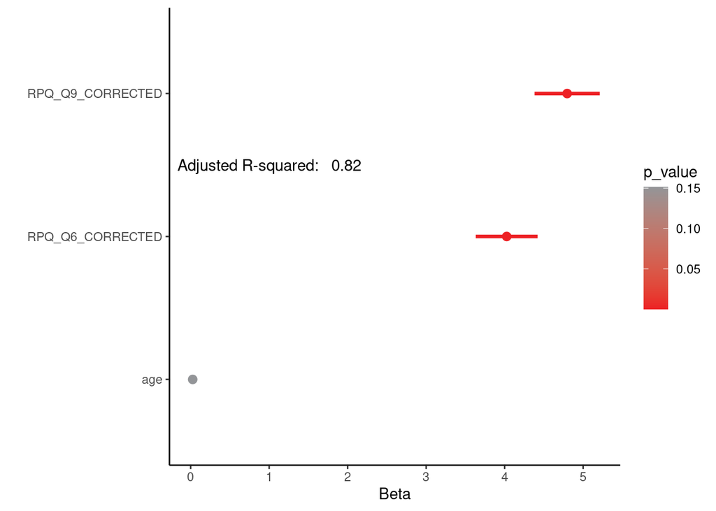

```r
rpq13_validation.lm_df = data.frame(name=row.names(summary(rpq13_validation.lm)$coefficients),cbind((cbind(Beta = coef(rpq13_validation.lm), confint(rpq13_validation.lm))), p_value = summary(rpq13_validation.lm)$coefficients[,4]))

write.csv(rpq13_validation.lm_df,"dt_out/rpq13_validation_lm.csv")

rpq13_validation.lm_df = subset(rpq13_validation.lm_df, name != "(Intercept)")

ggplot(rpq13_validation.lm_df,
       aes(x=reorder(name,Beta), y=Beta, color = p_value, fill = p_value)) +
    geom_point(shape=21, size = 2.5) +
    geom_errorbar(aes(ymin=X2.5.., ymax=X97.5..),
                  width=0,                    # Width of the error bars
                  size = 1.2,
                  position=position_dodge(.9)) +
  scale_color_gradient(
  low = "#ED2024",
  high = "#939598") +
  scale_fill_gradient(
  low = "#ED2024",
  high = "#939598") +
  theme_classic() +
  # geom_hline(yintercept = 1, linetype="dotted") +
  coord_flip()+ylab("Beta") +
  xlab("") +
  annotate("text", x = 2.5, y=1, label= "Adjusted R-squared:   0.82")
```

```r
ggsave('fig/rpq13_validation_lm.pdf', width = 4, height = 1.5,  bg = "transparent")
```

```r
cor.test(rpq3_validation$RPQ_Q9_CORRECTED, rpq3_validation$RPQ_Q6_CORRECTED)
```

```
##
##  Pearson's product-moment correlation
##
## data:  rpq3_validation$RPQ_Q9_CORRECTED and rpq3_validation$RPQ_Q6_CORRECTED
## t = 14.181, df = 467, p-value < 2.2e-16
## alternative hypothesis: true correlation is not equal to 0
## 95 percent confidence interval:
##  0.4820295 0.6089255
## sample estimates:
##       cor
## 0.5486293
```

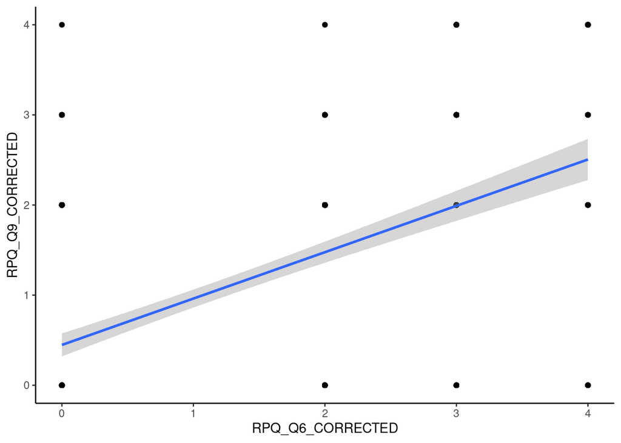

```r
rpq13_plot = na.omit(subset(rpq3_validation, select = c(RPQ_Q6_CORRECTED,RPQ_Q9_CORRECTED)))
ggplot(data = rpq13_plot, aes(x = RPQ_Q6_CORRECTED, y = RPQ_Q9_CORRECTED)) +
  geom_point() +
  geom_smooth(method = "lm") +
  theme_classic()
```

## Modifiable factors

### Dementia

```r
dt_noS_dementia = subset(dt_noS, select = c(mostRecentConcussion,
                                           RPQ13_CORRECTED,
                                           # BM7 +
                                           age,
                                           # ageStroopQscore +
                                           # concussions,
                                           # covidPositive +
                                           dementia
                                           # hadConcussion,
                                           # joke +
                                           # memory +
                                           # alcohol,
                                           # alcoholAmount,
                                           # smoking,
                                           # MCI_TOT
                                           ))
dt_noS_dementia = na.omit(dt_noS_dementia)
dt_noS_dementia$recent_concussion = with(dt_noS_dementia, ifelse(mostRecentConcussion %in%
                                                 c("New_User_ConcussionC_1",
                                                   "New_User_ConcussionC_2"), TRUE, FALSE))
dt_noS_dementia$dem_recoded = with(dt_noS_dementia, ifelse(dementia %in%
                                                 c("ResponseNo",
                                                   "ResponseDontKnow"), FALSE, TRUE))

dt_long_concuss = subset(dt_noS_dementia, recent_concussion == FALSE)

summary(rpq13_lm <-lm(data = dt_long_concuss, RPQ13_CORRECTED ~
                                           # BM7 +
                                           age +
                                           # ageStroopQscore +
                                           # concussions,
                                           # covidPositive +
                                           dementia# +
                                           # hadConcussion,
                                           # joke +
                                           # memory +
                                           # alcohol *
                                           # alcoholAmount +
                                           # smoking +
                                           # MCI_TOT
                                           # neuro_TOT +
                                           # MH_TOT
                                   ))
```

```
##
## Call:
## lm(formula = RPQ13_CORRECTED ~ age + dementia, data = dt_long_concuss)
##
## Residuals:
##     Min      1Q  Median      3Q     Max
## -17.709  -8.887  -2.916   6.569  34.649
##
## Coefficients:
##                     Estimate Std. Error t value Pr(>|t|)
## (Intercept)         16.40405    2.43715   6.731 5.24e-11 ***
## age                  0.05436    0.04112   1.322    0.187
## dementiaResponseNo  -9.55376    1.74688  -5.469 7.58e-08 ***
## dementiaResponseYes -7.44845    1.79393  -4.152 3.95e-05 ***
## ---
## Signif. codes:  0 '***' 0.001 '**' 0.01 '*' 0.05 '.' 0.1 ' ' 1
##
## Residual standard error: 11.15 on 443 degrees of freedom
## Multiple R-squared:  0.06568,    Adjusted R-squared:  0.05935
## F-statistic: 10.38 on 3 and 443 DF,  p-value: 1.297e-06
```

```r
rpq13_lm_dt = data.frame(cbind((cbind(Beta = coef(rpq13_lm), confint(rpq13_lm))), p_value = summary(rpq13_lm)$coefficients[,4]))

write.csv(rpq13_lm_dt,"dt_out/rpq13_lm_dt_dementia.csv", row.names=TRUE)
```

### Smoking

```r
dt_noS_subset = subset(dt_noS, select = c(mostRecentConcussion,
                                           RPQ13_CORRECTED,
                                           # BM7 +
                                           age,
                                           # ageStroopQscore +
                                           # concussions,
                                           # covidPositive +
                                           # dementia
                                           # hadConcussion,
                                           # joke +
                                           # memory +
                                           # alcohol,
                                           # alcoholAmount,
                                           smoking
                                           # MCI_TOT
                                           ))

dt_noS_subset$recent_concussion = with(dt_noS_subset, ifelse(mostRecentConcussion %in%
                                                 c("New_User_ConcussionC_1",
                                                   "New_User_ConcussionC_2"), TRUE, FALSE))

dt_long_concuss = subset(dt_noS_subset, recent_concussion == FALSE)

summary(rpq13_lm <-lm(data = dt_long_concuss, RPQ13_CORRECTED/52 ~
                                           # BM7 +
                                           age +
                                           # ageStroopQscore +
                                           # concussions,
                                           # covidPositive +
                                           # dementia# +
                                           # hadConcussion,
                                           # joke +
                                           # memory +
                                           # alcohol *
                                           # alcoholAmount +
                                           smoking
                                           # MCI_TOT
                                           # neuro_TOT +
                                           # MH_TOT
                                   ))
```

```
##
## Call:
## lm(formula = RPQ13_CORRECTED/52 ~ age + smoking, data = dt_long_concuss)
##
## Residuals:
##      Min       1Q   Median       3Q      Max
## -0.33932 -0.18275 -0.05848  0.12026  0.70571
##
## Coefficients:
##                               Estimate Std. Error t value Pr(>|t|)
## (Intercept)                  0.2805719  0.0464837   6.036 3.34e-09 ***
## age                          0.0009324  0.0008037   1.160  0.24657
## smokingNew_User_Smoke_Never -0.1281301  0.0313352  -4.089 5.15e-05 ***
## smokingNew_User_Smoke_Past  -0.1139325  0.0344976  -3.303  0.00104 **
## ---
## Signif. codes:  0 '***' 0.001 '**' 0.01 '*' 0.05 '.' 0.1 ' ' 1
##
## Residual standard error: 0.2175 on 443 degrees of freedom
##   (1766 observations deleted due to missingness)
## Multiple R-squared:  0.03895,    Adjusted R-squared:  0.03244
## F-statistic: 5.985 on 3 and 443 DF,  p-value: 0.0005269
```

```r
rpq13_lm_dt = data.frame(cbind((cbind(Beta = coef(rpq13_lm), confint(rpq13_lm))), p_value = summary(rpq13_lm)$coefficients[,4]))

write.csv(rpq13_lm_dt,"dt_out/rpq13_lm_dt_smoking.csv", row.names=TRUE)
```

### Alcohol

```r
dt_noS_subset = subset(dt_noS, select = c(mostRecentConcussion,
                                           RPQ13_CORRECTED,
                                           # BM7 +
                                           age,
                                           # ageStroopQscore +
                                           # concussions,
                                           # covidPositive +
                                           # dementia
                                           # hadConcussion,
                                           # joke +
                                           # memory +
                                           alcohol,
                                           alcoholAmount
                                           # smoking
                                           # MCI_TOT
                                           ))
dt_noS_subset = na.omit(dt_noS_subset)
dt_noS_subset$recent_concussion = with(dt_noS_subset, ifelse(mostRecentConcussion %in%
                                                 c("New_User_ConcussionC_1",
                                                   "New_User_ConcussionC_2"), TRUE, FALSE))

dt_long_concuss = subset(dt_noS_subset, recent_concussion == FALSE)

lvl.alcohol <- c("None","New_User_Alcohol_Amount_LT3","New_User_Alcohol_Amount_47","New_User_Alcohol_Amount_714","New_User_Alcohol_Amount_MT14")
lbl.alcohol <- c(0,1,2,3,4)
dt_long_concuss$alcohol_recoded <- ordered(dt_long_concuss$alcoholAmount, levels=lvl.alcohol, labels=lbl.alcohol)
dt_long_concuss$alcohol_recoded = as.numeric(dt_long_concuss$alcohol_recoded)

# dt_long_concuss$excessive_alcohol = with(dt_long_concuss, ifelse(alcoholAmount == "New_User_Alcohol_Amount_MT14",
#                                                    TRUE, FALSE))

summary(rpq13_lm <-lm(data = dt_long_concuss, RPQ13_CORRECTED ~
                                           # BM7 +
                                           age +
                                           # ageStroopQscore +
                                           # concussions,
                                           # covidPositive +
                                           # dementia# +
                                           # hadConcussion,
                                           # joke +
                                           # memory +
                                           # alcohol *
                                           alcoholAmount #+
                                           # smoking
                                           # MCI_TOT
                                           # neuro_TOT +
                                           # MH_TOT
                      # alcohol_recoded
                                   ))
```

```
##
## Call:
## lm(formula = RPQ13_CORRECTED ~ age + alcoholAmount, data = dt_long_concuss)
##
## Residuals:
##     Min      1Q  Median      3Q     Max
## -14.841  -9.378  -2.952   6.836  33.394
##
## Coefficients:
##                                           Estimate Std. Error t value Pr(>|t|)
## (Intercept)                                9.19124    2.20120   4.176 3.58e-05
## age                                        0.04938    0.04237   1.166   0.2444
## alcoholAmountNew_User_Alcohol_Amount_714  -3.07764    1.75215  -1.756   0.0797
## alcoholAmountNew_User_Alcohol_Amount_LT3  -0.99838    1.45688  -0.685   0.4935
## alcoholAmountNew_User_Alcohol_Amount_MT14  1.03370    2.25541   0.458   0.6469
## alcoholAmountNone                          1.99527    1.54922   1.288   0.1985
##
## (Intercept)                               ***
## age
## alcoholAmountNew_User_Alcohol_Amount_714  .
## alcoholAmountNew_User_Alcohol_Amount_LT3
## alcoholAmountNew_User_Alcohol_Amount_MT14
## alcoholAmountNone
## ---
## Signif. codes:  0 '***' 0.001 '**' 0.01 '*' 0.05 '.' 0.1 ' ' 1
##
## Residual standard error: 11.44 on 441 degrees of freedom
## Multiple R-squared:  0.02218,    Adjusted R-squared:  0.01109
## F-statistic:     2 on 5 and 441 DF,  p-value: 0.07745
```

```r
rpq13_lm_dt = data.frame(cbind((cbind(Beta = coef(rpq13_lm), confint(rpq13_lm))), p_value = summary(rpq13_lm)$coefficients[,4]))

write.csv(rpq13_lm_dt,"dt_out/rpq13_lm_dt_alcohol.csv", row.names=TRUE)
```

### MCI

```r
dt_noS_subset = subset(dt_noS, select = c(mostRecentConcussion,
                                           RPQ13_CORRECTED,
                                           # BM7 +
                                           age,
                                           # ageStroopQscore +
                                           # concussions,
                                           # covidPositive +
                                           # dementia
                                           # hadConcussion,
                                           # joke +
                                           # memory +
                                           # alcohol,
                                           # alcoholAmount
                                           # smoking
                                           MCI_TOT
                                           ))

dt_noS_subset$recent_concussion = with(dt_noS_subset, ifelse(mostRecentConcussion %in%
                                                 c("New_User_ConcussionC_1",
                                                   "New_User_ConcussionC_2"), TRUE, FALSE))

dt_long_concuss = subset(dt_noS_subset, recent_concussion == FALSE)

summary(rpq13_lm <-lm(data = dt_long_concuss, RPQ13_CORRECTED/52 ~
                                           # BM7 +
                                           age +
                                           # ageStroopQscore +
                                           # concussions,
                                           # covidPositive +
                                           # dementia# +
                                           # hadConcussion,
                                           # joke +
                                           # memory +
                                           # alcohol *
                                           # alcoholAmount #+
                                           # smoking
                                            MCI_TOT
                                           # neuro_TOT +
                                           # MH_TOT
                                   ))
```

```
##
## Call:
## lm(formula = RPQ13_CORRECTED/52 ~ age + MCI_TOT, data = dt_long_concuss)
##
## Residuals:
##      Min       1Q   Median       3Q      Max
## -0.51730 -0.16296 -0.02871  0.15378  0.60677
##
## Coefficients:
##             Estimate Std. Error t value Pr(>|t|)
## (Intercept) 0.120142   0.056609   2.122   0.0348 *
## age         0.001157   0.001101   1.051   0.2944
## MCI_TOT     0.066007   0.009300   7.098 1.45e-11 ***
## ---
## Signif. codes:  0 '***' 0.001 '**' 0.01 '*' 0.05 '.' 0.1 ' ' 1
##
## Residual standard error: 0.2153 on 238 degrees of freedom
##   (1972 observations deleted due to missingness)
## Multiple R-squared:  0.1781, Adjusted R-squared:  0.1712
## F-statistic:  25.8 on 2 and 238 DF,  p-value: 7.25e-11
```

```r
rpq13_lm_dt = data.frame(cbind((cbind(Beta = coef(rpq13_lm), confint(rpq13_lm))), p_value = summary(rpq13_lm)$coefficients[,4]))

write.csv(rpq13_lm_dt,"dt_out/rpq13_lm_dt_MCI.csv", row.names=TRUE)
```

### Plot

Note: do not show dementia because it’s hard to explain

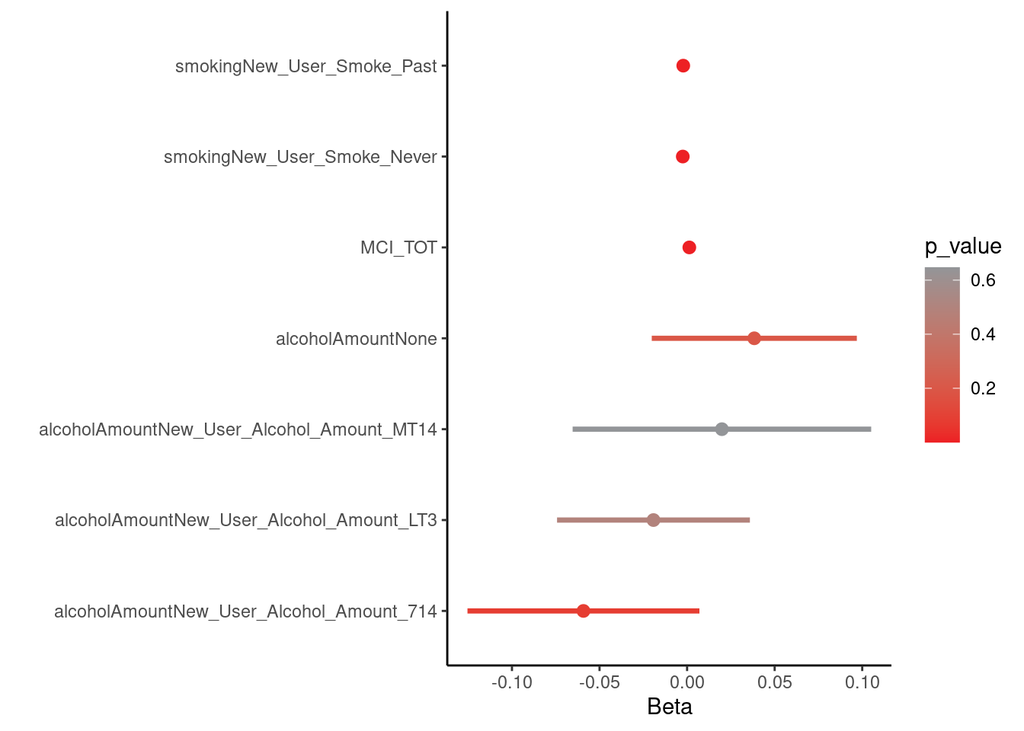

```r
plot.mci = read.csv("dt_out/rpq13_lm_dt_MCI.csv")
plot.alcohol = read.csv("dt_out/rpq13_lm_dt_alcohol.csv")
plot.smoking = read.csv("dt_out/rpq13_lm_dt_smoking.csv")
# plot.mci = read.csv("dt_out/rpq13_lm_dt_dementia.csv")
plot.sum = rbind(plot.smoking,plot.mci)
plot.sum = rbind(plot.sum,plot.alcohol)

plot.sum$significance = "p-value > 0.05"
plot.sum$significance[plot.sum$p_value < 0.05] <- "p-value < 0.05"

plot.sum = subset(plot.sum, X != "(Intercept)")
plot.sum = subset(plot.sum, X != "age")

ggplot2::ggplot(plot.sum,
       aes(x=X, y=Beta/52, color = p_value, fill = p_value)) +
    geom_point(shape=21, size = 2.5) +
    geom_errorbar(aes(ymin=X2.5../52, ymax=X97.5../52),
                  width=0,                    # Width of the error bars
                  size = 1.2,
                  position=position_dodge(.9)) +
  scale_color_gradient(
  low = "#ED2024",
  high = "#939598") +
  scale_fill_gradient(
  low = "#ED2024",
  high = "#939598") +
  theme_classic() +
  # geom_hline(yintercept = 1, linetype="dotted") +
  coord_flip()+ylab("Beta") +
  xlab("")
```

```r
ggsave("fig/long_concussion_rpq13_lm_MCI_smoking_alcohol.pdf", width = 7, height = 3,  bg = "transparent")
```

### Decision tree

```r
tr1 <- trainControl(
        method = 'LGOCV',
        number = 1,
        p = 0.75,
        savePredictions = TRUE)
m1 <- train(RPQ13_CORRECTED ~ .,
        data = dt_noS_rpq_tot_na,
        method = 'rpart2',
        tuneLength = 10,
        metric = 'MAE',
        trControl = tr1)
plot(m1)
```

[output not shown]

```r
rpart.plot(m1$finalModel)
```

[output not shown]